# AllLife Credit Card Customer Segmentation

## All Life Credit Card Customer Segmentation

### Background:

AllLife Bank wants to focus on its credit card customer base in the next financial year. They have been advised by their marketing research team, that the penetration in the market can be improved. Based on this input, the Marketing team proposes to run personalised campaigns to target new customers as well as upsell to existing customers. Another insight from the market research was that the customers perceive the support services of the back poorly. Based on this, the Operations team wants to upgrade the service delivery model, to ensure that customers queries are resolved faster. Head of Marketing and Head of Delivery both decide to reach out to the Data Science team for help.

Objective: To identify different segments in the existing customer based on their spending patterns as well as past interaction with the bank.

### Key Questions:

1. How many different segments of customers are there?
2. How are these segments different from each other?
3. What are your recommendations to the bank on how to better market to and service these customers?

### Data Description:

Data is of various customers of a bank with their credit limit, the total number of credit cards the customer has, and different channels through which customer has contacted the bank for any queries, different channels include visiting the bank, online and through a call centre.

### Steps to follow:

### **1. Perform univariate analysis on the data to better understand the variables at your disposal and to get an idea about the no of clusters. Perform EDA, create visualizations to explore data. (10 marks)**

```python
# To enable plotting graphs in Jupyter notebook
%matplotlib inline
```

```python
%%javascript
IPython.OutputArea.prototype._should_scroll = function(lines) {
    return false;
}
```

```python
# Numerical libraries
import numpy as np

from sklearn.model_selection import train_test_split

from sklearn.cluster import KMeans

# to handle data in form of rows and columns
import pandas as pd

# importing ploting libraries
import matplotlib.pyplot as plt

#importing seaborn for statistical plots
import seaborn as sns

from sklearn import metrics

import pandas as pd
```

```python
# reading the CSV file into pandas dataframe
ccdata = pd.read_excel("Credit Card Customer Data.xlsx")
```

```python
ccdata.head()
```

|  | Sl_No | Customer Key | Avg_Credit_Limit | Total_Credit_Cards | Total_visits_bank | Total_visits_online | Total_calls_made |
| --- | --- | --- | --- | --- | --- | --- | --- |
| 0 | 1 | 87073 | 100000 | 2 | 1 | 1 | 0 |
| 1 | 2 | 38414 | 50000 | 3 | 0 | 10 | 9 |
| 2 | 3 | 17341 | 50000 | 7 | 1 | 3 | 4 |
| 3 | 4 | 40496 | 30000 | 5 | 1 | 1 | 4 |
| 4 | 5 | 47437 | 100000 | 6 | 0 | 12 | 3 |

```python
ccdata.shape
```

```
(660, 7)
```

```python
ccdata.columns = ['sl_no', 'customer_key', 'avg_credit_limit', 'total_credit_cards',
       'total_visits_bank', 'total_visits_online', 'total_calls_made']
```

```python
cont_cols=['avg_credit_limit', 'total_credit_cards',
       'total_visits_bank', 'total_visits_online', 'total_calls_made']
```

```python
ccdata.info()
```

```
<class 'pandas.core.frame.DataFrame'>
RangeIndex: 660 entries, 0 to 659
Data columns (total 7 columns):
 #   Column               Non-Null Count  Dtype
---  ------               --------------  -----
 0   sl_no                660 non-null    int64
 1   customer_key         660 non-null    int64
 2   avg_credit_limit     660 non-null    int64
 3   total_credit_cards   660 non-null    int64
 4   total_visits_bank    660 non-null    int64
 5   total_visits_online  660 non-null    int64
 6   total_calls_made     660 non-null    int64
dtypes: int64(7)
memory usage: 36.2 KB
```

```python
ccdata.nunique()
```

```
sl_no                  660
customer_key           655
avg_credit_limit       110
total_credit_cards      10
total_visits_bank        6
total_visits_online     16
total_calls_made        11
dtype: int64
```

```python
# Check for missing value in any other column
ccdata.isna().sum()
```

```
sl_no                  0
customer_key           0
avg_credit_limit       0
total_credit_cards     0
total_visits_bank      0
total_visits_online    0
total_calls_made       0
dtype: int64
```

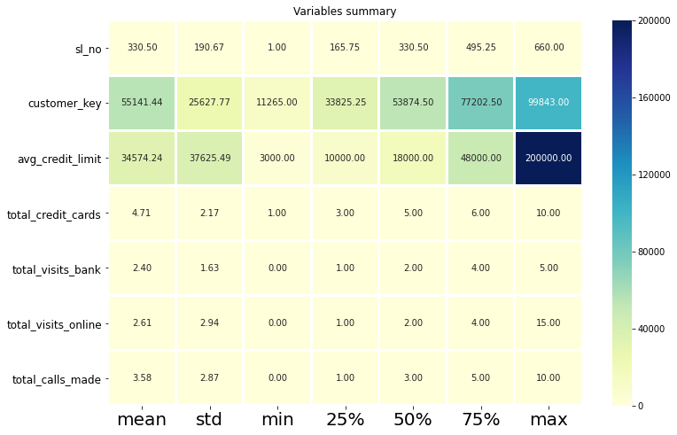

```python
plt.figure(figsize=(12,8))
sns.heatmap(round(ccdata.describe()[1:].transpose(),2),linewidth=2,annot=True,fmt=".2f", cmap="YlGnBu")
plt.xticks(fontsize=20)
plt.yticks(fontsize=12)
plt.title("Variables summary")
plt.show()
```

```python
def df_col_analysis(df, fieldName):
    maxVal= df[fieldName].max()
    minVal=df[fieldName].min()
    Q1=df[fieldName].quantile(q=0.25)
    Q3=df[fieldName].quantile(q=0.75)
    L_outliers=Q1-1.5*(Q3-Q1)
    U_outliers=Q3+1.5*(Q3-Q1)
    print('==========='+ fieldName.upper())
    print('Column Name : '+ fieldName)
    print('Range : ', minVal, ' to ', maxVal)
    print('Mean : ', df[fieldName].mean())
    print('Median : ', df[fieldName].median())
    print('Std Dev : ', df[fieldName].std())
    print('Lower outliers : ', L_outliers)
    print('Upper outliers : ', U_outliers)
    print('Number of outliers in  upper : ', df[df[fieldName]>U_outliers][fieldName].count())
    print('Number of outliers in  lower : ', df[df[fieldName]<L_outliers][fieldName].count())
    print('% of Outlier in  upper: ',round(df[df[fieldName]>U_outliers][fieldName].count()*100/len(df)), '%')
    print('% of Outlier in  lower: ',round(df[df[fieldName]<L_outliers][fieldName].count()*100/len(df)), '%')

    fig, (ax1,ax2)=plt.subplots(1,2,figsize=(13,5))

    #boxplot
    sns.boxplot(x=fieldName,data=df,orient='v',ax=ax1)
    ax1.set_ylabel(fieldName, fontsize=15)
    ax1.set_title('Distribution of '+ fieldName, fontsize=15)
    ax1.tick_params(labelsize=15)

    #distplot
    sns.distplot(df[fieldName])
```

```
===========AVG_CREDIT_LIMIT
Column Name : avg_credit_limit
Range :  3000  to  200000
Mean :  34574.242424242424
Median :  18000.0
Std Dev :  37625.48780422165
Lower outliers :  -47000.0
Upper outliers :  105000.0
Number of outliers in  upper :  39
Number of outliers in  lower :  0
% of Outlier in  upper:  6.0 %
% of Outlier in  lower:  0.0 %
```

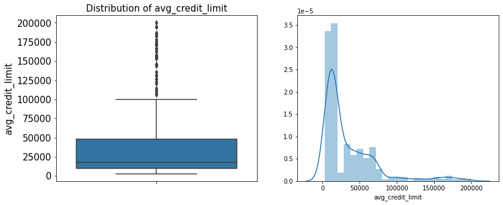

```python
df_col_analysis(ccdata,'avg_credit_limit')
```

```
===========TOTAL_CREDIT_CARDS
Column Name : total_credit_cards
Range :  1  to  10
Mean :  4.706060606060606
Median :  5.0
Std Dev :  2.1678348595111934
Lower outliers :  -1.5
Upper outliers :  10.5
Number of outliers in  upper :  0
Number of outliers in  lower :  0
% of Outlier in  upper:  0.0 %
% of Outlier in  lower:  0.0 %
```

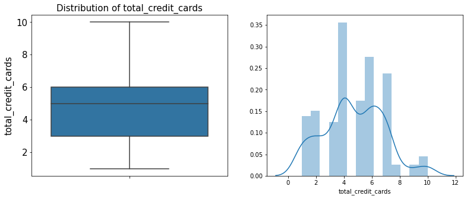

```python
df_col_analysis(ccdata,'total_credit_cards')
```

```
===========TOTAL_VISITS_BANK
Column Name : total_visits_bank
Range :  0  to  5
Mean :  2.403030303030303
Median :  2.0
Std Dev :  1.6318128757916113
Lower outliers :  -3.5
Upper outliers :  8.5
Number of outliers in  upper :  0
Number of outliers in  lower :  0
% of Outlier in  upper:  0.0 %
% of Outlier in  lower:  0.0 %
```

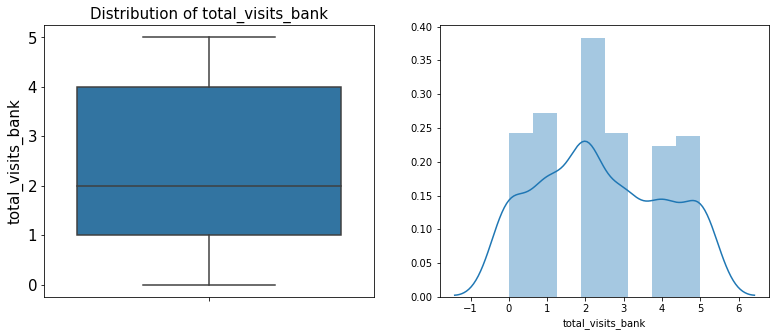

```python
df_col_analysis(ccdata,'total_visits_bank')
```

```python
# Obeservation: visible clusters .. 3 major cluster
```

```
===========TOTAL_VISITS_ONLINE
Column Name : total_visits_online
Range :  0  to  15
Mean :  2.606060606060606
Median :  2.0
Std Dev :  2.9357241204935414
Lower outliers :  -3.5
Upper outliers :  8.5
Number of outliers in  upper :  37
Number of outliers in  lower :  0
% of Outlier in  upper:  6.0 %
% of Outlier in  lower:  0.0 %
```

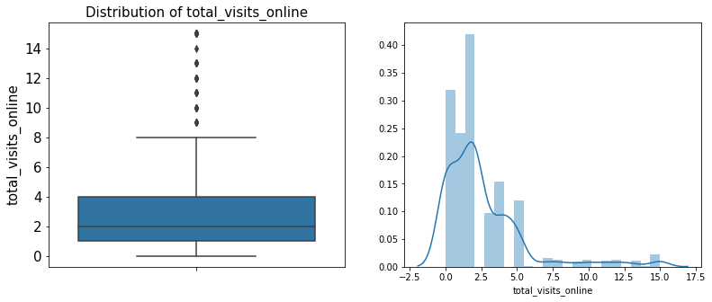

```python
df_col_analysis(ccdata,'total_visits_online')
```

```
===========TOTAL_CALLS_MADE
Column Name : total_calls_made
Range :  0  to  10
Mean :  3.5833333333333335
Median :  3.0
Std Dev :  2.865316817622708
Lower outliers :  -5.0
Upper outliers :  11.0
Number of outliers in  upper :  0
Number of outliers in  lower :  0
% of Outlier in  upper:  0.0 %
% of Outlier in  lower:  0.0 %
```

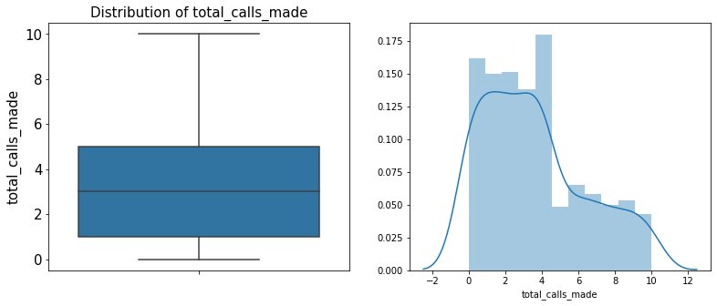

```python
df_col_analysis(ccdata,'total_calls_made')
```

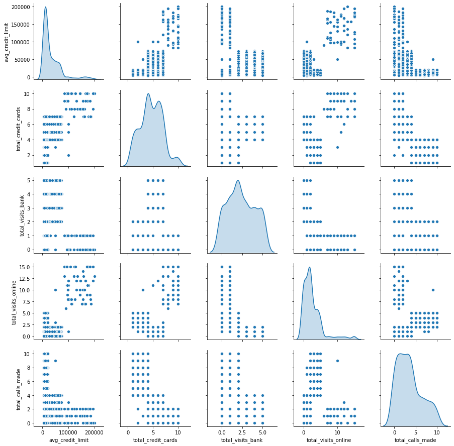

```python
sns.pairplot(ccdata.iloc[:,2:],diag_kind='kde')
```

### **2. Properly comment on the codes, provide explanations of the steps taken in the notebook and conclude your insights from the graphs. (5 marks)**

### Observations

From diagonal plots we can see

- avg_credit_limit has 2 major peaks and 1 tail peak
- total_credit_cards - shows four peaks majorily
- total_visits_bank - is majorly 3 but 2 minor clusters
- total_visits_online shows 1 major but 3 minor clusters
- total_calls_made shows 3 clusters

From bivariate plots we can observe:

- positive liner relationship with total_visits_online with avg_credit_limit and total_credit_cards
- total_calls_made shows negative correlation with avg_credit_limit
- Customer with lower credit limit or less cards make more calls/ bank visits then online, and vice versa

### **3. Execute K-means clustering use elbow plot and analyse clusters using boxplot (10 marks)**

```python
##Scale the data
from scipy.stats import zscore
ccdata_org = ccdata.copy()
ccdata = ccdata.iloc[:, 2:]
ccdata_z = ccdata.apply(zscore)
```

```python
ccdata_z.head()
```

|  | avg_credit_limit | total_credit_cards | total_visits_bank | total_visits_online | total_calls_made |
| --- | --- | --- | --- | --- | --- |
| 0 | 1.740187 | -1.249225 | -0.860451 | -0.547490 | -1.251537 |
| 1 | 0.410293 | -0.787585 | -1.473731 | 2.520519 | 1.891859 |
| 2 | 0.410293 | 1.058973 | -0.860451 | 0.134290 | 0.145528 |
| 3 | -0.121665 | 0.135694 | -0.860451 | -0.547490 | 0.145528 |
| 4 | 1.740187 | 0.597334 | -1.473731 | 3.202298 | -0.203739 |

```python
results_df = pd.DataFrame()
```

```
cluster : 1 : silhouette_score : 0
cluster : 2 : silhouette_score : 0.41842496663215445
cluster : 3 : silhouette_score : 0.5157182558881063
cluster : 4 : silhouette_score : 0.3556670619372605
cluster : 5 : silhouette_score : 0.2717470361089752
cluster : 6 : silhouette_score : 0.25583657571102003
cluster : 7 : silhouette_score : 0.24969750265579418
cluster : 8 : silhouette_score : 0.2263145201528689
cluster : 9 : silhouette_score : 0.2091150498130439
```

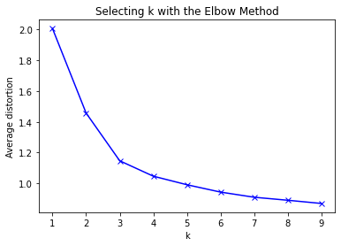

```python
#Finding optimal no. of clusters
from scipy.spatial.distance import cdist
from sklearn.metrics import silhouette_score, adjusted_rand_score
clusters=range(1,10)
meanDistortions=[]

for k in clusters:
    model=KMeans(n_clusters=k)
    model.fit(ccdata_z)
    prediction=model.predict(ccdata_z)
    meanDistortions.append(sum(np.min(cdist(ccdata_z, model.cluster_centers_, 'euclidean'), axis=1)) / ccdata_z
                           .shape[0])
    if k == 1 :
        sscore= 0;
    else :
        sscore = silhouette_score(ccdata_z, model.labels_)
    print('cluster :', k , ': silhouette_score :' , sscore)
    resultMap= {'1_Cluster' : 'KMeans', '2_no_of_cluster' : k,
                '3_silhouette_score' : sscore}
    results_df=results_df.append(resultMap,ignore_index=True)

plt.plot(clusters, meanDistortions, 'bx-')
plt.xlabel('k')
plt.ylabel('Average distortion')
plt.title('Selecting k with the Elbow Method')
```

```python
#Set the value of k=3
kmeans = KMeans(n_clusters=3, n_init = 15, random_state=2345)
```

```python
kmeans.fit(ccdata_z)

prediction=kmeans.predict(ccdata_z)
centroids = kmeans.cluster_centers_
```

```python
centroids
```

```
array([[-0.59579625, -1.05962278, -0.9015185 ,  0.32299678,  1.14810882],
       [-0.02106178,  0.37368962,  0.6663945 , -0.55367163, -0.55300488],
       [ 2.83176409,  1.86222621, -1.10576269,  2.82731942, -0.87432983]])
```

```python
#Calculate the centroids
centroid_df = pd.DataFrame(centroids, columns = list(ccdata_z) )
```

```python
print(centroid_df)
```

```
   avg_credit_limit  total_credit_cards  total_visits_bank  \
0         -0.595796           -1.059623          -0.901518
1         -0.021062            0.373690           0.666395
2          2.831764            1.862226          -1.105763

   total_visits_online  total_calls_made
0             0.322997          1.148109
1            -0.553672         -0.553005
2             2.827319         -0.874330
```

```python
#Append the prediction
ccdata_z["GROUP"] = prediction
ccdata["GROUP"] = prediction
print("Groups Assigned : \n")
ccdata.head()
```

```
Groups Assigned :
```

|  | avg_credit_limit | total_credit_cards | total_visits_bank | total_visits_online | total_calls_made | GROUP |
| --- | --- | --- | --- | --- | --- | --- |
| 0 | 100000 | 2 | 1 | 1 | 0 | 1 |
| 1 | 50000 | 3 | 0 | 10 | 9 | 0 |
| 2 | 50000 | 7 | 1 | 3 | 4 | 1 |
| 3 | 30000 | 5 | 1 | 1 | 4 | 1 |
| 4 | 100000 | 6 | 0 | 12 | 3 | 2 |

```python
# Calculate silhouette_score
sscore = silhouette_score(ccdata_z, kmeans.labels_)
print ('Silhouette_score:', sscore)
```

```
Silhouette_score: 0.5397786437631975
```

```python
kmeans_3_ccdataClust = ccdata.groupby(['GROUP'])
kmeans_3_ccdataClust.mean()
```

| GROUP | avg_credit_limit | total_credit_cards | total_visits_bank | total_visits_online | total_calls_made |
| --- | --- | --- | --- | --- | --- |
| 0 | 12174.107143 | 2.410714 | 0.933036 | 3.553571 | 6.870536 |
| 1 | 33782.383420 | 5.515544 | 3.489637 | 0.981865 | 2.000000 |
| 2 | 141040.000000 | 8.740000 | 0.600000 | 10.900000 | 1.080000 |

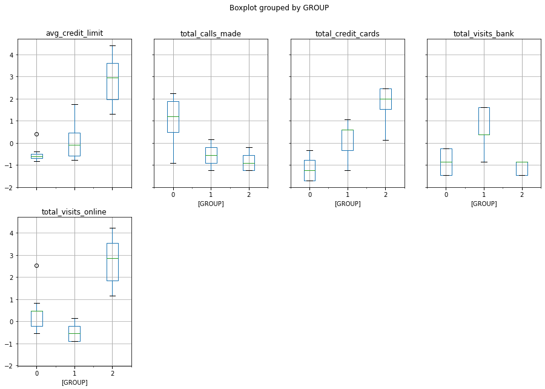

```python
ccdata_z.boxplot(by='GROUP', layout = (2,4),figsize=(15,10))
plt.show()
```

```python
results_df
```

|  | 1_Cluster | 2_no_of_cluster | 3_silhouette_score |
| --- | --- | --- | --- |
| 0 | KMeans | 1.0 | 0.000000 |
| 1 | KMeans | 2.0 | 0.418425 |
| 2 | KMeans | 3.0 | 0.515718 |
| 3 | KMeans | 4.0 | 0.355667 |
| 4 | KMeans | 5.0 | 0.271747 |
| 5 | KMeans | 6.0 | 0.255837 |
| 6 | KMeans | 7.0 | 0.249698 |
| 7 | KMeans | 8.0 | 0.226315 |
| 8 | KMeans | 9.0 | 0.209115 |

### **4. Execute hierarchical clustering (with different linkages) with the help of dendrogram and cophenetic coeff. Analyse clusters formed using boxplot (15 marks)**

```python
def clusterbylinkage(results_df,ccdata, ccdata_z,linkageType):
    from scipy.cluster.hierarchy import cophenet, dendrogram, linkage
    from scipy.spatial.distance import pdist  #Pairwise distribution between data points
    from sklearn.cluster import AgglomerativeClustering

    print('===========LINKAGE:' + linkageType.upper())
    # cophenet index is a measure of the correlation between the distance of points in feature space and distance on dendrogram
    # closer it is to 1, the better is the clustering
    if 'GROUP' in ccdata_z.columns:
        ccdata_z= ccdata_z.drop('GROUP',1)
    if 'GROUP' in ccdata.columns:
        ccdata=ccdata.drop('GROUP',1)

    Z = linkage(ccdata_z, metric='euclidean', method='complete')
    c, coph_dists = cophenet(Z , pdist(ccdata_z))

    print ('Cophenet index: ', c)
    plt.figure(figsize=(10, 5))
    plt.title('Agglomerative Hierarchical Clustering Dendogram: LINKAGE: '+ linkageType)
    plt.xlabel('sample index')
    plt.ylabel('Distance')
    dendrogram(Z, leaf_rotation=90.,color_threshold = 40, leaf_font_size=8. )
    plt.tight_layout()
    plt.show()

    for num_clusters in range(2,5):
        #num_clusters=3
        print ('  ===')
        print ('  === LINKAGE:' + linkageType.upper() + ' : num_clusters:', num_clusters)
        # Hint: Use truncate_mode='lastp' attribute in dendrogram function to arrive at dendrogram
        dendrogram(
            Z,
            truncate_mode='lastp',  # show only the last p merged clusters
            p=num_clusters # show only the last p merged clusters
        )
        plt.show()


        model = AgglomerativeClustering(n_clusters=num_clusters, affinity='euclidean',  linkage=linkageType)
        prediction=model.fit_predict(ccdata_z)
        # Calculate silhouette_score
        silhouettescore = silhouette_score(ccdata_z, prediction)
        print ('Silhouette_score:', silhouettescore)
        #Append the prediction
        ccdata_z["GROUP"] = prediction
        ccdata["GROUP"] = prediction
#         print("Groups Assigned : \n")
#         print(ccdata.head())
        ccdataClust = ccdata.groupby(['GROUP'])
        print("Groups Mean : \n")
        print(ccdataClust.mean())

        print("BOX PLOT : \n")
        ccdata_z.boxplot(by='GROUP', layout = (2,4),figsize=(15,10))
        plt.show()
        resultMap= {'1_Cluster' : 'AgglomerativeClustering-'+linkageType, '2_no_of_cluster' : num_clusters,
                '3_silhouette_score' : silhouettescore, '4_cophenet_index': c}
        results_df=results_df.append(resultMap,ignore_index=True)

    return results_df;
```

```
===========LINKAGE:AVERAGE
Cophenet index:  0.8599730607972423
```

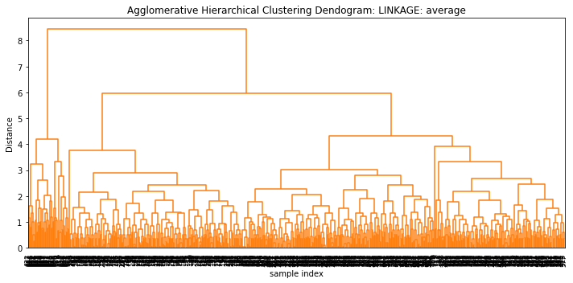

```
  ===
  === LINKAGE:AVERAGE : num_clusters: 2
```

```
Silhouette_score: 0.5703183487340514
Groups Mean :

       avg_credit_limit  total_credit_cards  total_visits_bank  \
GROUP
0          25847.540984             4.37541            2.55082
1         141040.000000             8.74000            0.60000

       total_visits_online  total_calls_made
GROUP
0                  1.92623          3.788525
1                 10.90000          1.080000
BOX PLOT :
```

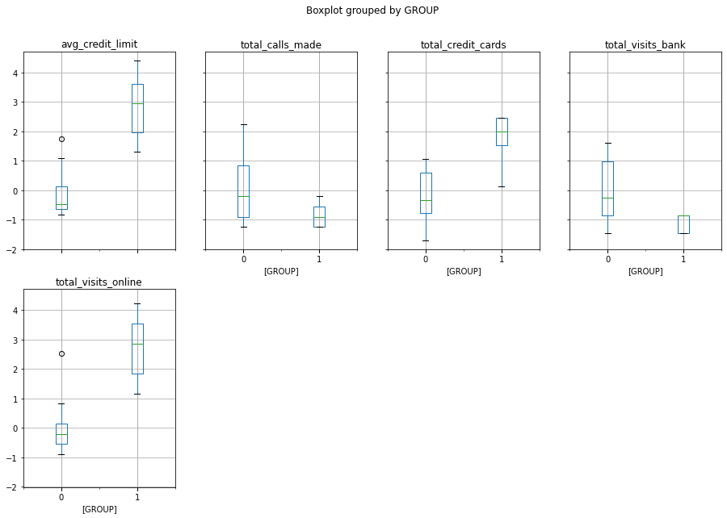

```
  ===
  === LINKAGE:AVERAGE : num_clusters: 3
```

```
Silhouette_score: 0.5165552811938575
Groups Mean :

       avg_credit_limit  total_credit_cards  total_visits_bank  \
GROUP
0          33713.178295            5.511628           3.485788
1         141040.000000            8.740000           0.600000
2          12197.309417            2.403587           0.928251

       total_visits_online  total_calls_made
GROUP
0                 0.984496          2.005168
1                10.900000          1.080000
2                 3.560538          6.883408
BOX PLOT :
```

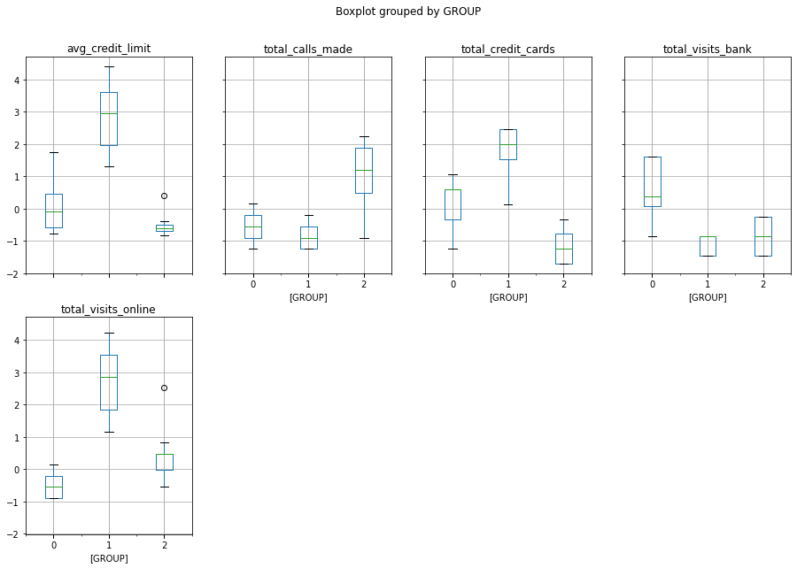

```
  ===
  === LINKAGE:AVERAGE : num_clusters: 4
```

```
Silhouette_score: 0.51800640075783
Groups Mean :

       avg_credit_limit  total_credit_cards  total_visits_bank  \
GROUP
0          12197.309417            2.403587           0.928251
1         141040.000000            8.740000           0.600000
2          33541.450777            5.520725           3.492228
3         100000.000000            2.000000           1.000000

       total_visits_online  total_calls_made
GROUP
0                 3.560538          6.883408
1                10.900000          1.080000
2                 0.984456          2.010363
3                 1.000000          0.000000
BOX PLOT :
```

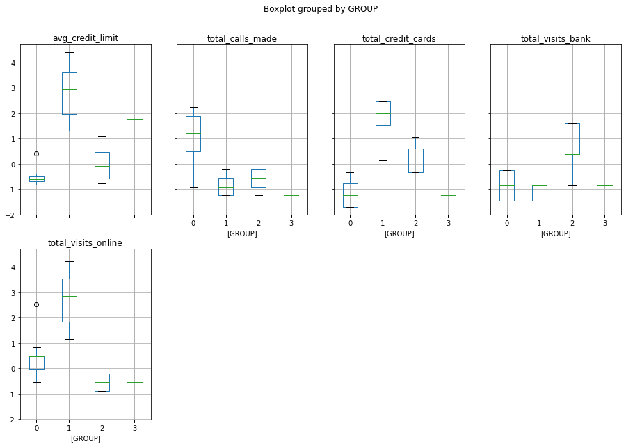

```python
# linkage "average" analysis
results_df=clusterbylinkage(results_df, ccdata,ccdata_z, 'average')
```

```python
results_df
```

|  | 1_Cluster | 2_no_of_cluster | 3_silhouette_score | 4_cophenet_index |
| --- | --- | --- | --- | --- |
| 0 | KMeans | 1.0 | 0.000000 | NaN |
| 1 | KMeans | 2.0 | 0.418425 | NaN |
| 2 | KMeans | 3.0 | 0.515718 | NaN |
| 3 | KMeans | 4.0 | 0.355667 | NaN |
| 4 | KMeans | 5.0 | 0.271747 | NaN |
| 5 | KMeans | 6.0 | 0.255837 | NaN |
| 6 | KMeans | 7.0 | 0.249698 | NaN |
| 7 | KMeans | 8.0 | 0.226315 | NaN |
| 8 | KMeans | 9.0 | 0.209115 | NaN |
| 9 | AgglomerativeClustering-average | 2.0 | 0.570318 | 0.859973 |
| 10 | AgglomerativeClustering-average | 3.0 | 0.516555 | 0.859973 |
| 11 | AgglomerativeClustering-average | 4.0 | 0.518006 | 0.859973 |

```
===========LINKAGE:COMPLETE
Cophenet index:  0.8599730607972423
```

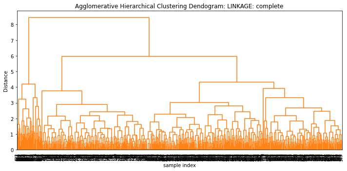

```
  ===
  === LINKAGE:COMPLETE : num_clusters: 2
```

```
Silhouette_score: 0.5703183487340514
Groups Mean :

       avg_credit_limit  total_credit_cards  total_visits_bank  \
GROUP
0          25847.540984             4.37541            2.55082
1         141040.000000             8.74000            0.60000

       total_visits_online  total_calls_made
GROUP
0                  1.92623          3.788525
1                 10.90000          1.080000
BOX PLOT :
```

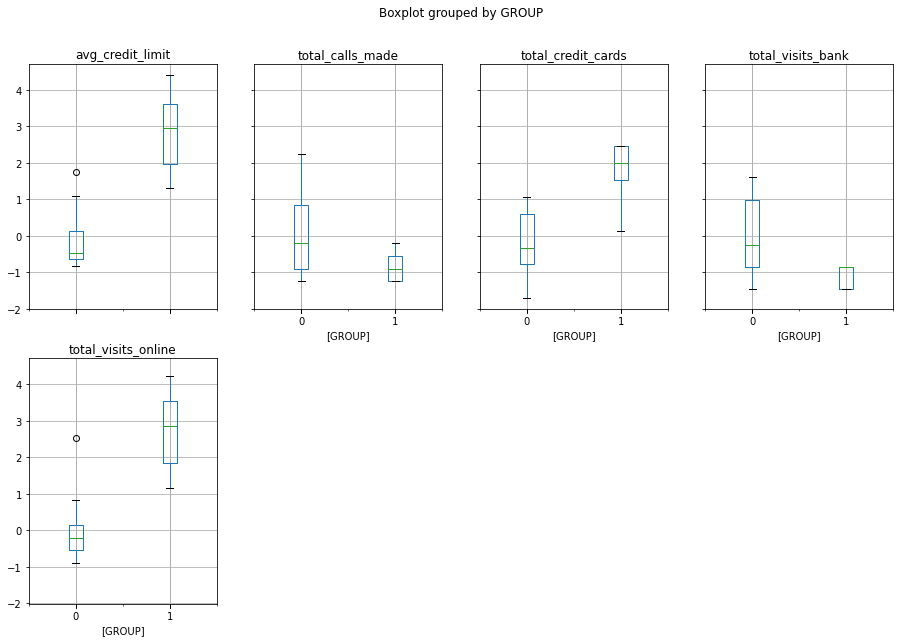

```
  ===
  === LINKAGE:COMPLETE : num_clusters: 3
```

```
Silhouette_score: 0.5032718121086658
Groups Mean :

       avg_credit_limit  total_credit_cards  total_visits_bank  \
GROUP
0          33151.133501            5.460957           3.405542
1         141040.000000            8.740000           0.600000
2          12234.741784            2.352113           0.957746

       total_visits_online  total_calls_made
GROUP
0                 1.010076          2.060453
1                10.900000          1.080000
2                 3.633803          7.009390
BOX PLOT :
```

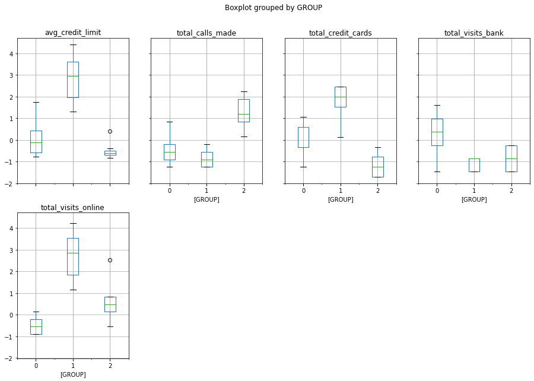

```
  ===
  === LINKAGE:COMPLETE : num_clusters: 4
```

```
Silhouette_score: 0.34716326727679403
Groups Mean :

       avg_credit_limit  total_credit_cards  total_visits_bank  \
GROUP
0         141040.000000            8.740000           0.600000
1          29331.250000            5.350000           2.318750
2          12234.741784            2.352113           0.957746
3          35729.957806            5.535865           4.139241

       total_visits_online  total_calls_made
GROUP
0                10.900000          1.080000
1                 1.006250          2.550000
2                 3.633803          7.009390
3                 1.012658          1.729958
BOX PLOT :
```

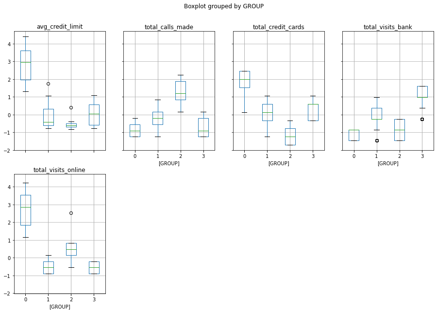

```python
## linkage "complete" analysis
results_df=clusterbylinkage(results_df,ccdata,ccdata_z, 'complete')
```

```
===========LINKAGE:WARD
Cophenet index:  0.8599730607972423
```

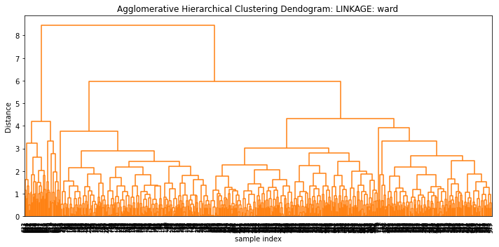

```
  ===
  === LINKAGE:WARD : num_clusters: 2
```

```
Silhouette_score: 0.417704147620949
Groups Mean :

       avg_credit_limit  total_credit_cards  total_visits_bank  \
GROUP
0          46172.413793            5.887356           3.160920
1          12151.111111            2.422222           0.937778

       total_visits_online  total_calls_made
GROUP
0                 2.119540          1.889655
1                 3.546667          6.857778
BOX PLOT :
```

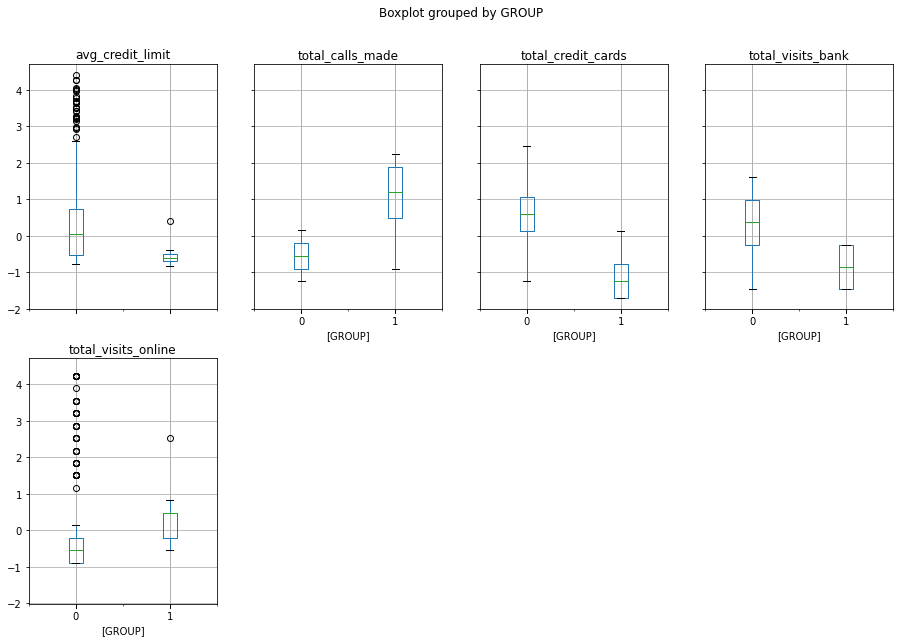

```
  ===
  === LINKAGE:WARD : num_clusters: 3
```

```
Silhouette_score: 0.5382676976124992
Groups Mean :

       avg_credit_limit  total_credit_cards  total_visits_bank  \
GROUP
0          33851.948052            5.516883           3.493506
1          12151.111111            2.422222           0.937778
2         141040.000000            8.740000           0.600000

       total_visits_online  total_calls_made
GROUP
0                 0.979221          1.994805
1                 3.546667          6.857778
2                10.900000          1.080000
BOX PLOT :
```

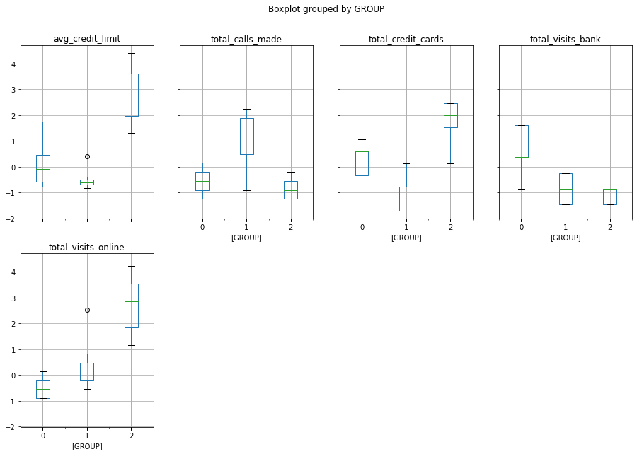

```
  ===
  === LINKAGE:WARD : num_clusters: 4
```

```
Silhouette_score: 0.3613368111508486
Groups Mean :

       avg_credit_limit  total_credit_cards  total_visits_bank  \
GROUP
0          12151.111111            2.422222           0.937778
1          38298.429319            5.670157           2.523560
2         141040.000000            8.740000           0.600000
3          29474.226804            5.365979           4.448454

       total_visits_online  total_calls_made
GROUP
0                 3.546667          6.857778
1                 0.947644          2.099476
2                10.900000          1.080000
3                 1.010309          1.891753
BOX PLOT :
```

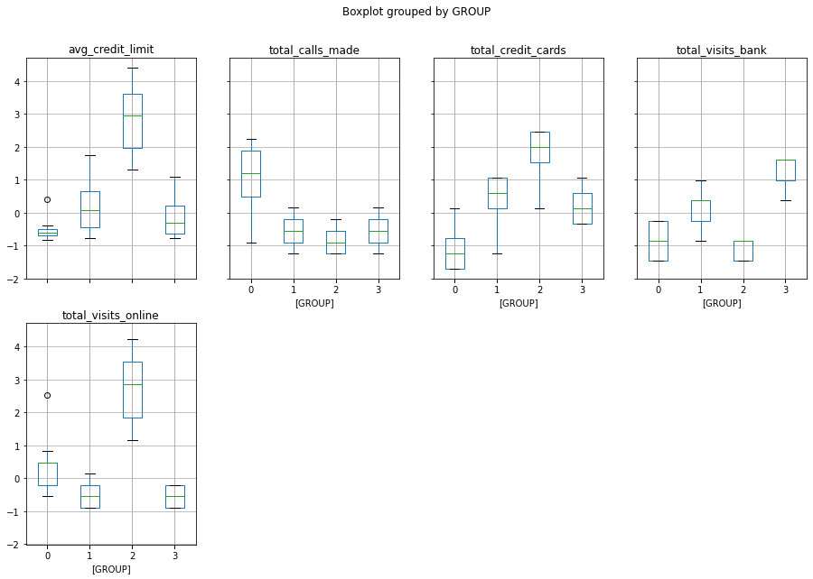

```python
## linkage ward analysis

results_df=clusterbylinkage(results_df,ccdata,ccdata_z, 'ward')
```

```python
results_df
```

|  | 1_Cluster | 2_no_of_cluster | 3_silhouette_score | 4_cophenet_index |
| --- | --- | --- | --- | --- |
| 0 | KMeans | 1.0 | 0.000000 | NaN |
| 1 | KMeans | 2.0 | 0.418425 | NaN |
| 2 | KMeans | 3.0 | 0.515718 | NaN |
| 3 | KMeans | 4.0 | 0.355667 | NaN |
| 4 | KMeans | 5.0 | 0.271747 | NaN |
| 5 | KMeans | 6.0 | 0.255837 | NaN |
| 6 | KMeans | 7.0 | 0.249698 | NaN |
| 7 | KMeans | 8.0 | 0.226315 | NaN |
| 8 | KMeans | 9.0 | 0.209115 | NaN |
| 9 | AgglomerativeClustering-average | 2.0 | 0.570318 | 0.859973 |
| 10 | AgglomerativeClustering-average | 3.0 | 0.516555 | 0.859973 |
| 11 | AgglomerativeClustering-average | 4.0 | 0.518006 | 0.859973 |
| 12 | AgglomerativeClustering-complete | 2.0 | 0.570318 | 0.859973 |
| 13 | AgglomerativeClustering-complete | 3.0 | 0.503272 | 0.859973 |
| 14 | AgglomerativeClustering-complete | 4.0 | 0.347163 | 0.859973 |
| 15 | AgglomerativeClustering-ward | 2.0 | 0.417704 | 0.859973 |
| 16 | AgglomerativeClustering-ward | 3.0 | 0.538268 | 0.859973 |
| 17 | AgglomerativeClustering-ward | 4.0 | 0.361337 | 0.859973 |

```python
##Oberservation : reviewing the silhouette scores of KMeans cluustering and AgglomerativeClustering
### KMenas suggest 3 clusters
### AgglomerativeClustering-ward suggests 3 clusters
### AgglomerativeClustering-average and complete suggests 2 clusters
```

```python
def clusterbylinkageAndCluster(ccdata, ccdata_z,linkageType, num_clusters):
    from scipy.cluster.hierarchy import cophenet, dendrogram, linkage
    from scipy.spatial.distance import pdist  #Pairwise distribution between data points
    from sklearn.cluster import AgglomerativeClustering

    print('===========LINKAGE:' + linkageType.upper())
    # cophenet index is a measure of the correlation between the distance of points in feature space and distance on dendrogram
    # closer it is to 1, the better is the clustering
    if 'GROUP' in ccdata_z.columns:
        ccdata_z= ccdata_z.drop('GROUP',1)
    if 'GROUP' in ccdata.columns:
        ccdata=ccdata.drop('GROUP',1)
      #num_clusters=3
        print ('  ===')
        print ('  === LINKAGE:' + linkageType.upper() + ' : num_clusters:', num_clusters)
        # Hint: Use truncate_mode='lastp' attribute in dendrogram function to arrive at dendrogram

    model = AgglomerativeClustering(n_clusters=num_clusters, affinity='euclidean',  linkage=linkageType)
    prediction=model.fit_predict(ccdata_z)

    silhouettescore = silhouette_score(ccdata_z, prediction)
    print ('Silhouette_score:', silhouettescore)
    #Append the prediction
    ccdata_z["GROUP"] = prediction
    ccdata["GROUP"] = prediction
#         print("Groups Assigned : \n")
#         print(ccdata.head())
    ccdataClust = ccdata.groupby(['GROUP'])
    print("Groups Mean : \n")
    print(ccdataClust.mean())
    return ccdataClust;
```

```python
ward_ccdataClust= clusterbylinkageAndCluster(ccdata,ccdata_z, 'ward', 3)
```

[output not shown]

```python
ward_ccdataClust.count()
```

| GROUP | avg_credit_limit | total_credit_cards | total_visits_bank | total_visits_online | total_calls_made |
| --- | --- | --- | --- | --- | --- |
| 0 | 385 | 385 | 385 | 385 | 385 |
| 1 | 225 | 225 | 225 | 225 | 225 |
| 2 | 50 | 50 | 50 | 50 | 50 |

### **5. Calculate average silhouette score for both methods. (5 marks)**

```python
# the silhouette score for KMeans and AgglomerativeClustering with various linkages
results_df
```

|  | 1_Cluster | 2_no_of_cluster | 3_silhouette_score | 4_cophenet_index |
| --- | --- | --- | --- | --- |
| 0 | KMeans | 1.0 | 0.000000 | NaN |
| 1 | KMeans | 2.0 | 0.418425 | NaN |
| 2 | KMeans | 3.0 | 0.515718 | NaN |
| 3 | KMeans | 4.0 | 0.355667 | NaN |
| 4 | KMeans | 5.0 | 0.271747 | NaN |
| 5 | KMeans | 6.0 | 0.255837 | NaN |
| 6 | KMeans | 7.0 | 0.249698 | NaN |
| 7 | KMeans | 8.0 | 0.226315 | NaN |
| 8 | KMeans | 9.0 | 0.209115 | NaN |
| 9 | AgglomerativeClustering-average | 2.0 | 0.570318 | 0.859973 |
| 10 | AgglomerativeClustering-average | 3.0 | 0.516555 | 0.859973 |
| 11 | AgglomerativeClustering-average | 4.0 | 0.518006 | 0.859973 |
| 12 | AgglomerativeClustering-complete | 2.0 | 0.570318 | 0.859973 |
| 13 | AgglomerativeClustering-complete | 3.0 | 0.503272 | 0.859973 |
| 14 | AgglomerativeClustering-complete | 4.0 | 0.347163 | 0.859973 |
| 15 | AgglomerativeClustering-ward | 2.0 | 0.417704 | 0.859973 |
| 16 | AgglomerativeClustering-ward | 3.0 | 0.538268 | 0.859973 |
| 17 | AgglomerativeClustering-ward | 4.0 | 0.361337 | 0.859973 |

```python
mean1= results_df.groupby(['1_Cluster']).mean()
```

```python
#average
mean1[['3_silhouette_score']]
```

| 1_Cluster | 3_silhouette_score |
| --- | --- |
| AgglomerativeClustering-average | 0.534960 |
| AgglomerativeClustering-complete | 0.473584 |
| AgglomerativeClustering-ward | 0.439103 |
| KMeans | 0.278058 |

### **6. Compare K-means clusters with Hierarchical clusters. (5 marks)**

## Oberservation :

Reviewing the silhouette scores of KMeans cluustering and AgglomerativeClustering:

- KMeans suggest 3 clusters
- AgglomerativeClustering-ward suggests 3 clusters
- AgglomerativeClustering-average and complete suggests 2 clusters
- reviewing the distribution of the data, 3 cluster would optimal. Hence: AgglomerativeClustering-ward is selected

### **7. Analysis the clusters formed, tell us how is one cluster different from another and answer all the key questions. (10 marks)**

### 7.1. How many different segments of customers are there?

Based of cluster mean properties,

- both clusters from KMeans and AgglomerativeClustering-ward are quite similar in distribution and 3 cluster are optimized distribution

```python
kmeans_3_ccdataClust.mean()
```

| GROUP | avg_credit_limit | total_credit_cards | total_visits_bank | total_visits_online | total_calls_made |
| --- | --- | --- | --- | --- | --- |
| 0 | 12174.107143 | 2.410714 | 0.933036 | 3.553571 | 6.870536 |
| 1 | 33782.383420 | 5.515544 | 3.489637 | 0.981865 | 2.000000 |
| 2 | 141040.000000 | 8.740000 | 0.600000 | 10.900000 | 1.080000 |

```python
kmeans_3_ccdataClust.count()
```

| GROUP | avg_credit_limit | total_credit_cards | total_visits_bank | total_visits_online | total_calls_made |
| --- | --- | --- | --- | --- | --- |
| 0 | 224 | 224 | 224 | 224 | 224 |
| 1 | 386 | 386 | 386 | 386 | 386 |
| 2 | 50 | 50 | 50 | 50 | 50 |

### 7.2. How are these segments different from each other?

```python
# we will use the following segments for our reference as  AgglomerativeClustering-ward distribution is also inline.
kmeans_3_ccdataClust.mean()
```

| GROUP | avg_credit_limit | total_credit_cards | total_visits_bank | total_visits_online | total_calls_made |
| --- | --- | --- | --- | --- | --- |
| 0 | 12174.107143 | 2.410714 | 0.933036 | 3.553571 | 6.870536 |
| 1 | 33782.383420 | 5.515544 | 3.489637 | 0.981865 | 2.000000 |
| 2 | 141040.000000 | 8.740000 | 0.600000 | 10.900000 | 1.080000 |

```python
kmeans_3_ccdataClust.count()
```

| GROUP | avg_credit_limit | total_credit_cards | total_visits_bank | total_visits_online | total_calls_made |
| --- | --- | --- | --- | --- | --- |
| 0 | 224 | 224 | 224 | 224 | 224 |
| 1 | 386 | 386 | 386 | 386 | 386 |
| 2 | 50 | 50 | 50 | 50 | 50 |

### Observation

Just looking at ‘avg_credit_limit’ we can see that the model has identified some low , medium and High Credit limit segments.

Let’s understand the differences between these three segments to further determine why they are in separate clusters.

We can see that cluster 3 ( group 2) has a higher number of avg_credit_limit, more total_credit_cards, they make frequent online tranactions and are less likely to visit Bank. There is scope to inform/educate them to increase Online transctions

We can see that cluster 1 ( group 0)has a lower number of avg_credit_limit, less total_credit_cards, they make frequent calls and are less likely to visit Bank.

We can see that cluster 2 ( group 1)make maximuum bank visits and are less likely to do online tranctions

We can draw the conclusion that these are different segments of customers with different support/access needs and therefore there will almost certainly be a difference between how you support to these customers.

### 7.3. What are your recommendations to the bank on how to better market to and service these customers?

```python
kmeans_3_ccdataClust.mean()
```

| GROUP | avg_credit_limit | total_credit_cards | total_visits_bank | total_visits_online | total_calls_made |
| --- | --- | --- | --- | --- | --- |
| 0 | 12174.107143 | 2.410714 | 0.933036 | 3.553571 | 6.870536 |
| 1 | 33782.383420 | 5.515544 | 3.489637 | 0.981865 | 2.000000 |
| 2 | 141040.000000 | 8.740000 | 0.600000 | 10.900000 | 1.080000 |

```python
kmeans_3_ccdataClust.count()
```

| GROUP | avg_credit_limit | total_credit_cards | total_visits_bank | total_visits_online | total_calls_made |
| --- | --- | --- | --- | --- | --- |
| 0 | 224 | 224 | 224 | 224 | 224 |
| 1 | 386 | 386 | 386 | 386 | 386 |
| 2 | 50 | 50 | 50 | 50 | 50 |